# Prak02_StatistikDeskriptif

```python
#import packages untuk analisis deskriptif
import pandas as pd
```

```python
import numpy as np
```

```python
import matplotlib.pyplot as plt
```

```python
#Memasukkan Data
Students=pd.read_csv("StudentsPerformance.csv")
Students.head()
```

|  | gender | race/ethnicity | parental level of education | lunch | test preparation course | math score | reading score | writing score |
| --- | --- | --- | --- | --- | --- | --- | --- | --- |
| 0 | female | group B | bachelor's degree | standard | none | 72 | 72 | 74 |
| 1 | female | group C | some college | standard | completed | 69 | 90 | 88 |
| 2 | female | group B | master's degree | standard | none | 90 | 95 | 93 |
| 3 | male | group A | associate's degree | free/reduced | none | 47 | 57 | 44 |
| 4 | male | group C | some college | standard | none | 76 | 78 | 75 |

```python
Students.info()
```

```
<class 'pandas.core.frame.DataFrame'>
RangeIndex: 1000 entries, 0 to 999
Data columns (total 8 columns):
 #   Column                       Non-Null Count  Dtype
---  ------                       --------------  -----
 0   gender                       1000 non-null   object
 1   race/ethnicity               1000 non-null   object
 2   parental level of education  1000 non-null   object
 3   lunch                        1000 non-null   object
 4   test preparation course      1000 non-null   object
 5   math score                   1000 non-null   int64
 6   reading score                1000 non-null   int64
 7   writing score                1000 non-null   int64
dtypes: int64(3), object(5)
memory usage: 62.6+ KB
```

## Soal 1 : Sebutkan 2 tipe data yang dipelajari di kuliah ! Tipe data objek di python berarti termasuk yang mana ?

String,integer,boolean Tipe data objek di python berarti termasuk yang mana ? String

```python
df=pd.DataFrame(Students, columns=['math score', 'reading score', 'writing score']).mean()
df
```

```
math score       66.089
reading score    69.169
writing score    68.054
dtype: float64
```

```python
#Analisis Deskriptif
des = Students['math score'].describe()
des
```

```
count    1000.00000
mean       66.08900
std        15.16308
min         0.00000
25%        57.00000
50%        66.00000
75%        77.00000
max       100.00000
Name: math score, dtype: float64
```

```python
#Membuat Data Frame
df=pd.DataFrame(Students, columns=['gender','math score'])
```

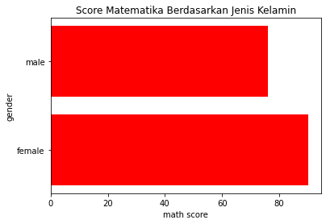

```python
indeks=np.array(df['gender'])
plt.barh(indeks[1:10],df['math score'].iloc[1:10],color="r")
plt.title('Score Matematika Berdasarkan Jenis Kelamin')
plt.xlabel('math score')
plt.ylabel('gender')
```

```python
plt.show()
```

Dari plot dapat dilihat bahwa siswa berjenis kelamin perempuan memperoleh nilai matematika lebih tinggi dari pada siswa laki-laki yaitu lebih dari 80, sedangkan siswa laki-laki hanya lebih dari 60 kurang dari 80.

## Soal02 : Buatlah kode agar warna grafik batang menjadi hijau !

```python
#Membuat Data Frame
df=pd.DataFrame(Students, columns=['gender','math score'])
```

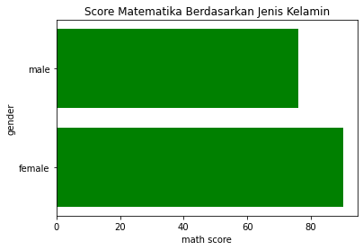

```python
indeks=np.array(df['gender'])
plt.barh(indeks[1:10],df['math score'].iloc[1:10],color="g")
plt.title('Score Matematika Berdasarkan Jenis Kelamin')
plt.xlabel('math score')
plt.ylabel('gender')
```

```python
#Membuat Data Frame
df=pd.DataFrame(Students, columns=['lunch','math score'])
```

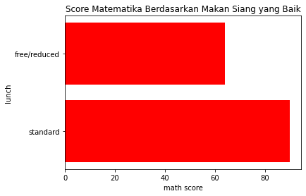

```python
indeks=np.array(df['lunch'])
plt.barh(indeks[1:10],df['math score'].iloc[1:10],color="r")
plt.title('Score Matematika Berdasarkan Makan Siang yang Baik')
plt.xlabel('math score')
plt.ylabel('lunch')
```

Terlihat dari gambar bahwa score matematika yang lebih baik karna makan siang yang standard dan score matematika yang kurang baik karena makanan free